# Size and Orientation: Match effects across three langauges

Sau-Chin Chen

Tzu-Chi University

Bjorn de Koning

Erasmus University Rotterdam

Yu-Han Luo

National Cheng-Kung University

Rolf Zwaan

Erasmus University Rotterdam

2017-03-29

### Hypothesis

In our pre-registered proposal: “Match effects of object orientation in the sentence-picture verification task are consistently smaller than object shape, color, and size. We hypothesize that this may be due to the fact that the orientation objects are small and manipulable. This study asks the questions if object size constrains object orientation effects, such that effects for smaller, manipulable, items are smaller than for larger, nonmanipulable objects. A pilot study yielded larger match effects for the large objects than for the small objects both in English and in Dutch speakers. In addition, a Bayesian analysis indicated that the stronger match effect occurred for the horizontal objects of English participants and the stronger match effect happened to the vertical objects of Dutch participants. The pre-registered experiment will update the design of sentence-picture verification based on our pilots and test the hypotheses in advance. A third language, Chinese, will be included to test the stronger match effect for the large objects than the small objects and to confirm the inconsistent match effects across horizontal and vertical objects. Alternative recognition trials will be triggered after each eight trials. These recognition trials are used to make sure the participants have paid their attentions on the probe sentences. Meta-analyses will be performed on the data for the three experiments. We expect that effects generalize across languages and therefore that language will not be a signficant moderator of the observed effects.”

### Method

#### Stimuli and Design

64 sets of critical stimuli are decided by the language backgrounds (English, Dutch, and Chinese), the object size (Large, Small), the object orientation (Horizontal, Verticl), and the matching the probe sentence and target picture(match, mismatch). Half of the sets represent the large objects, and the other half represent the small objects. In each set two pictures show the target object in horizontal and in vertical respectively. The format of target pictures are the grey scaled jpeg files in 240 X 240 pixels. Each picture matches one of the probe sentence whereas mismatches the other probe sentence. Every probe sentence are written in English, Dutch, and Chinese for the participants in the respective langauge backgrounds. The objects are the initial nouns of the probe sentences. We used this sentence strucure according to our earlier pilot study.

##### Examples of large objects

Matched Picture

Mismatched Picture

The canoe was gliding across the river.

The canoe was dropping from the top of the water fall.

##### Examples of small objects

Matched Picture

Mismatched Picture

The hat was on the model’s head.

The hat hung on the wall.

64 filler pairs of sentences and pictures are decided for the demand of verification task. In each pair the picture are irrelavent to the sentence. The sentence strucure and the picture format are identical to the critical stimuli.

#### Procedure

The experimental session began after 6 practice trials. Each practice trial is the sentence-picture verification task as identical to the settings of Stanfield and Zwaan(2001) and Zwaan and Pechers (2012). Because the limitations of experimental software, the English participants finished the 6 practices trials with feedback, but the Dutch and Chinese participants finished the pratice session till they correctly answered all the 6 practice trials.

The experimental session had 128 trials of sentence-picture verifiaction task and 30 to 32 trials of the alternative task. For the English participants, the alternative task is the comprehension task follows the settings of Zwaan and Pechers (2012). 32 multiple choices present after 32 fillers. These trials require the participants answer the questions about the probe sentences they just read. For the Dutch and Chinese participants, the alternative task is recognition task as like Stanfield and Zwaan (2001). 30 yes/no problems present randomly between the 128 experimental trials. These problems require the participant recognize if the sentence just shown in the recent three trials or not.

### Results

#### Descriptive Analysis

This table summarizes the the median reaction tiems, mean reaction times, and the average accuracy in the function of languages, object size, object orientation, and the matching of sentence and picture. This descriptive analysis and the mixed ANOVA in the next section reveal which variables to be analyzed in the analysis plans.

|  | Median RT | Mean RT | Average Accuracy(%) |
| --- | --- | --- | --- |
| C, Large Size, Horizontal, Mismatch | 664.80 | 683.40 | 91.62 |
| C, Large Size, Horizontal, Match | 663.00 | 683.10 | 94.38 |
| C, Large Size, Vertical, Mismatch | 688.00 | 700.70 | 91.88 |
| C, Large Size, Vertical, Match | 673.50 | 690.80 | 94.12 |
| C, Small Size, Horizontal, Mismatch | 621.50 | 636.10 | 90.88 |
| C, Small Size, Horizontal, Match | 632.00 | 649.30 | 92.62 |
| C, Small Size, Vertical, Mismatch | 599.80 | 623.20 | 91.75 |
| C, Small Size, Vertical, Match | 619.80 | 634.20 | 94.38 |
| D, Large Size, Horizontal, Mismatch | 685.80 | 697.30 | 95.12 |
| D, Large Size, Horizontal, Match | 703.20 | 719.40 | 95.75 |
| D, Large Size, Vertical, Mismatch | 718.20 | 737.20 | 93.12 |
| D, Large Size, Vertical, Match | 682.20 | 701.10 | 95.12 |
| D, Small Size, Horizontal, Mismatch | 626.20 | 641.80 | 93.00 |
| D, Small Size, Horizontal, Match | 632.00 | 641.60 | 94.25 |
| D, Small Size, Vertical, Mismatch | 642.00 | 651.20 | 92.00 |
| D, Small Size, Vertical, Match | 628.20 | 639.70 | 94.12 |
| E, Large Size, Horizontal, Mismatch | 674.50 | 700.30 | 93.16 |
| E, Large Size, Horizontal, Match | 670.30 | 695.60 | 93.75 |
| E, Large Size, Vertical, Mismatch | 687.30 | 714.30 | 92.77 |
| E, Large Size, Vertical, Match | 661.30 | 684.70 | 92.28 |
| E, Small Size, Horizontal, Mismatch | 624.10 | 640.50 | 93.36 |
| E, Small Size, Horizontal, Match | 612.90 | 632.60 | 95.02 |
| E, Small Size, Vertical, Mismatch | 610.10 | 639.60 | 93.85 |
| E, Small Size, Vertical, Match | 634.40 | 645.10 | 94.24 |

This figure illustrates the match effects across object size and languages. The object orientations are merged under each object size.

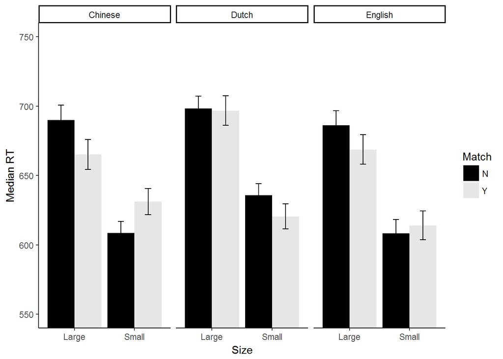

#### Primay analysis: ANOVA

In the pre-registered proposal:“A 2 (size) X 2 (orientation) X 2 (match) X 3 (language) mixed ANOVA will be conducted on the participants’ median response times. This ANOVA will indicate the match effects interacting with object size, orientation, and languages.”

This analysis told us which variables to be investigated in the analysis plans.

|  | Df | Sum Sq | Mean Sq | F value | Pr(>F) |
| --- | --- | --- | --- | --- | --- |
| Lang | 2.000 | 104707.913 | 52353.957 | 0.730 | 0.483 |
| Residuals | 325.000 | 23317766.204 | 71746.973 |  |  |
| Size | 1.000 | 2433608.825 | 2433608.825 | 377.317 | 0.000 |
| Lang:Size | 2.000 | 28172.690 | 14086.345 | 2.184 | 0.114 |
| Residuals1 | 325.000 | 2096176.427 | 6449.774 |  |  |
| Orientation | 1.000 | 7624.455 | 7624.455 | 1.347 | 0.247 |
| Lang:Orientation | 2.000 | 6430.571 | 3215.286 | 0.568 | 0.567 |
| Residuals | 325.000 | 1840007.867 | 5661.563 |  |  |
| Match | 1.000 | 13161.824 | 13161.824 | 2.422 | 0.121 |
| Lang:Match | 2.000 | 19181.504 | 9590.752 | 1.765 | 0.173 |
| Residuals | 325.000 | 1765808.530 | 5433.257 |  |  |
| Size:Orientation | 1.000 | 12112.033 | 12112.033 | 2.853 | 0.092 |
| Lang:Size:Orientation | 2.000 | 26822.397 | 13411.199 | 3.159 | 0.044 |
| Residuals | 325.000 | 1379780.079 | 4245.477 |  |  |
| Size:Match | 1.000 | 22890.025 | 22890.025 | 4.425 | 0.036 |
| Lang:Size:Match | 2.000 | 8265.259 | 4132.629 | 0.799 | 0.451 |
| Residuals | 325.000 | 1681375.920 | 5173.464 |  |  |
| Orientation:Match | 1.000 | 35151.861 | 35151.861 | 5.925 | 0.015 |
| Lang:Orientation:Match | 2.000 | 29023.521 | 14511.761 | 2.446 | 0.088 |
| Residuals | 325.000 | 1928280.236 | 5933.170 |  |  |
| Size:Orientation:Match | 1.000 | 40637.728 | 40637.728 | 7.109 | 0.008 |
| Lang:Size:Orientation:Match | 2.000 | 10785.983 | 5392.992 | 0.943 | 0.390 |
| Residuals | 325.000 | 1857907.605 | 5716.639 |  |  |

The four-way mixed ANOVA indicates the object orientations could be merged. We conducted the three-way mixed ANOVA to confirm the significant main effect and interaction.

|  | Df | Sum Sq | Mean Sq | F value | Pr(>F) |
| --- | --- | --- | --- | --- | --- |
| Lang | 2.000 | 45203.453 | 22601.727 | 0.643 | 0.526 |
| Residuals | 325.000 | 11424254.409 | 35151.552 |  |  |
| Size | 1.000 | 1166163.503 | 1166163.503 | 343.634 | 0.000 |
| Lang:Size | 2.000 | 7210.638 | 3605.319 | 1.062 | 0.347 |
| Residuals1 | 325.000 | 1102926.455 | 3393.620 |  |  |
| Match | 1.000 | 3871.395 | 3871.395 | 1.453 | 0.229 |
| Lang:Match | 2.000 | 9400.458 | 4700.229 | 1.764 | 0.173 |
| Residuals | 325.000 | 865995.423 | 2664.601 |  |  |
| Size:Match | 1.000 | 9944.939 | 9944.939 | 3.687 | 0.056 |
| Lang:Size:Match | 2.000 | 19890.545 | 9945.273 | 3.687 | 0.026 |
| Residuals | 325.000 | 876657.632 | 2697.408 |  |  |

The three-way ANOVA shows the significant main effect of object size, `F(1,325) = 343.63, MSE = 3393.62, p = 0`, but the interaction of size and match effect turns out marginal, `F(1,325) = 3.69, MSE = 2697.41, p = 0.056`.

##### Brief discussion on the analysis of response times

From the four-way ANOVA to the three-way ANOVA, the interaction of language, size, and match turns out significant after the orientations were merged. This demonstrates the match effects of Chinese being dissimilar to those of English and Dutch.

A mixed four-way ANOVA is conducted on the accuracy data.

|  | Df | Sum Sq | Mean Sq | F value | Pr(>F) |
| --- | --- | --- | --- | --- | --- |
| Lang | 2.000 | 757.605 | 378.803 | 2.609 | 0.075 |
| Residuals | 325.000 | 47189.648 | 145.199 |  |  |
| Size | 1.000 | 21.496 | 21.496 | 0.271 | 0.603 |
| Lang:Size | 2.000 | 785.169 | 392.584 | 4.943 | 0.008 |
| Residuals1 | 325.000 | 25814.429 | 79.429 |  |  |
| Orientation | 1.000 | 57.224 | 57.224 | 0.814 | 0.368 |
| Lang:Orientation | 2.000 | 278.542 | 139.271 | 1.981 | 0.140 |
| Residuals | 325.000 | 22847.827 | 70.301 |  |  |
| Match | 1.000 | 1251.965 | 1251.965 | 13.389 | 0.000 |
| Lang:Match | 2.000 | 370.520 | 185.260 | 1.981 | 0.140 |
| Residuals | 325.000 | 30389.233 | 93.505 |  |  |
| Size:Orientation | 1.000 | 142.971 | 142.971 | 1.820 | 0.178 |
| Lang:Size:Orientation | 2.000 | 10.349 | 5.175 | 0.066 | 0.936 |
| Residuals | 325.000 | 25530.273 | 78.555 |  |  |
| Size:Match | 1.000 | 26.260 | 26.260 | 0.343 | 0.559 |
| Lang:Size:Match | 2.000 | 46.689 | 23.345 | 0.305 | 0.738 |
| Residuals | 325.000 | 24907.520 | 76.639 |  |  |
| Orientation:Match | 1.000 | 0.536 | 0.536 | 0.007 | 0.932 |
| Lang:Orientation:Match | 2.000 | 152.394 | 76.197 | 1.050 | 0.351 |
| Residuals | 325.000 | 23577.539 | 72.546 |  |  |
| Size:Orientation:Match | 1.000 | 1.489 | 1.489 | 0.021 | 0.886 |
| Lang:Size:Orientation:Match | 2.000 | 25.880 | 12.940 | 0.180 | 0.836 |
| Residuals | 325.000 | 23390.601 | 71.971 |  |  |

#### Primay analysis: Meta-analysis

In the pre-registered proposal: “A meta-analytic effect size of the match effects across languages, size, and orientation will be summarized. This meta-analysis will confirm that the match effects could shift with the object size and orientations but have a stable pattern across languages.”

In this meta analysis, the effect size of match effects for each object size are calculated based on participants’ median RT and standardize deviation. . The intervals represent the match advantage/disadvantage estimated by the difference of medians.

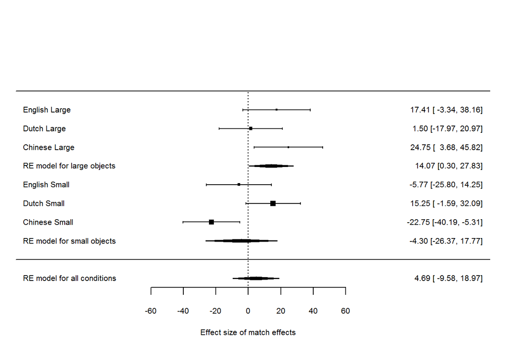

The meta analysis of random-effect model indicates the match advantage for the large objects. The forest plot indicats the contribution of Chinese data to the overall match advantage. As for the small objects, the mismatch advantage of Chinese data decreases the overall match effect. The Dutch data shows the pattern of match advantage for the small objects. However, this pattern was implicit in the forest plot at 2017, Jan.

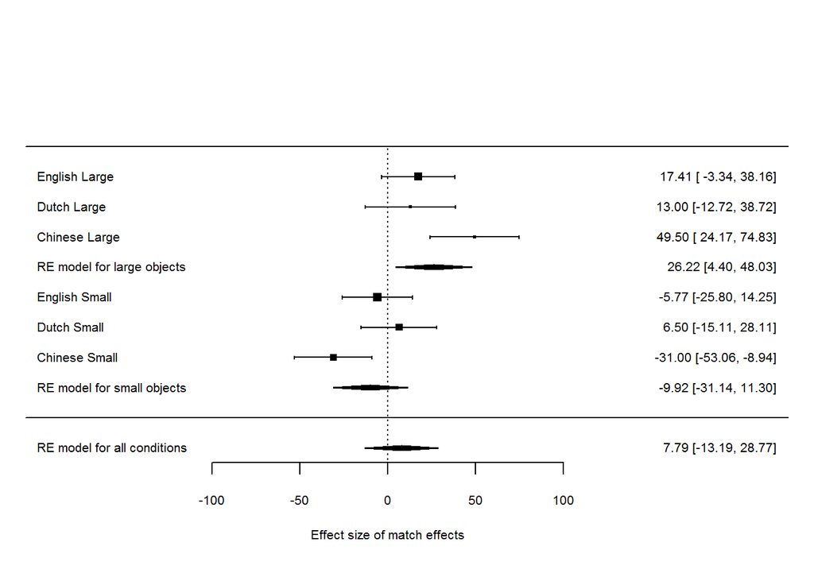

Patterns of every group at 2017, January

#### Secondary analysis: Bayesian Statistics

In the pre-registered proposal: “We calculate Bayes factor of each match effect as the evidence resulted from the given object size, orientation, and the participants’ native language.”

###### Bayes Factors

We run the one-tailed Baysian t test for the six sets of match effects. The Bayes factors that favored the match advantage (BFplus0) and the mismatch advantage (BF0plus) are calculated.

|  | dataset | BFplus0 | BF0plus |
| --- | --- | --- | --- |
| 1 | Chinese_Large | 0.36 | 0.05 |
| 2 | Chinese_Small | 0.04 | 1.61 |
| 3 | Dutch_Large | 0.07 | 0.20 |
| 4 | Dutch_Small | 0.32 | 0.06 |
| 5 | English_Large | 10.57 | 0.03 |
| 6 | English_Small | 0.09 | 0.10 |

Because the Bayes Factors for each condition are calculated in terms of the mean reaction times, we run the Baysian meta-analytic t tests (Rouder and Morey, 2011) for the data of large objects and small objects respectively. The t tests for each language group are summarized by the difference of the median RTs and the sampling variance of each condition.

```r
## Preparte the Bayesian meta t statistics
raw_t <- dat_2IV_es$yi/sqrt(dat_2IV_es$vi)
raw_n <- dat_2IV_es$ni
## Meta-analytic BF for Large Objects
extractBF(meta.ttestBF(t=raw_t[c(1,3,5)], n1=raw_n[c(1,3,5)], nullInterval = c(0, Inf), rscale = 1))$bf[1]
```

```
## [1] 1.387791
```

```r
## Meta-analytic BF for Small Objects
extractBF(meta.ttestBF(t=raw_t[c(2,4,6)], n1=raw_n[c(2,4,6)], nullInterval = c(-Inf,0), rscale = 1))$bf[1]
```

```
## [1] 0.09170095
```

##### BF models

To make sure the interaction of object size and match effects, the models contained ‘Size:Match’ are analyzed by Bayesian ANOVA. In the data for the forest plot, there are four models (see below) have ‘Size:Match’. The Bayes Factors of this interaction are calculated based on the demonstration of Rouder, Engelhardt, McCabe, & Morey (2016). The prior (r scale) for the fixed effects is 0.5, and the prior for the random effect (by subject variations) is 1. The interaction of object size and match effects is embedded in the four models as following.

```r
require(BayesFactor)
load("bf_2IV.RData")
## Numerator: Size + Match + Size:Match + ID
## Denominator: Size + Match + ID
extractBF(bf_2IV[13]/bf_2IV[7])$bf
```

```
## [1] 0.4524482
```

```r
## Numerator: Lang + Size + Match + Size:Match + ID
## Denominator: Lang + Size + Match + ID
extractBF(bf_2IV[14]/bf_2IV[8])$bf
```

```
## [1] 0.4761045
```

```r
## Numerator: Lang + Size + Lang:Size + Match + Size:Match + ID
## Denominator: Lang + Size + Lang:Size + Match + ID
extractBF(bf_2IV[15]/bf_2IV[9])$bf
```

```
## [1] 0.4207922
```

```r
## Numerator: Lang + Size + Match + Lang:Match + Size:Match + ID
## Denominator: Lang + Size + Match + Lang:Match + ID
extractBF(bf_2IV[16]/bf_2IV[11])$bf
```

```
## [1] 0.3885286
```

This data set is seperated to the set of large objects and the set of small objects. The analysis shows the larger Bayes Factor for the large objects. However, neither large objects nor small objects have the Bayes Factor > 1.

```r
require(BayesFactor)
## Large objects
extractBF(bf_2IV_Large[3]/bf_2IV_Large[1])$bf
```

```
## [1] 0.7009494
```

```r
## Small objects
extractBF(bf_2IV_Small[3]/bf_2IV_Small[1])$bf
```

```
## [1] 0.1056289
```

The comparisons between models indicate the object size has the largest accountibility for the match effects. This is consistent with the meta-analytical effects that the large objects show the significant match advantage, and the small objects show the tendency of mismatch advantage.

#### Secondary analysis: Comprehension and Recognition task

In the pre-registered proposal: “The average accuracies of the recognition trails and the comprehension task will be summarized by the participant. The average accuracy of every language group is compared to 50% which assume the participant had not read the probe sentence carefully. In the laboratory experiment, thirty recognition trials randomly present between the experimental trails. In the internet experiment, 32 comprehension trials present after the filler items.”

|  | Averaged Accuracies(%) | t | df | p value |
| --- | --- | --- | --- | --- |
| Chinese | 79.15 | 27.28 | 99.00 | 0.00 |
| Dutch | 78.21 | 29.09 | 99.00 | 0.00 |
| English | 83.79 | 28.00 | 127.00 | 0.00 |

Each group of participants complete the second task in the accuracies significantly higher than 50%.

### Discussion: Comfirmatory Analysis

In the beginning of our pre-registered plan, “we expect that (match) effects generalize across languages and therefore that language will not be a signficant moderator of the observed effects.” The current results show the match effects changed among the three languages. The meta-analytical effect of small objects is consistent with the weak match advantage in the past studies. Among the three language groups, the Dutch data showed the tendency of match advantage. On the other hand, the meta-analytical effect of large objects confirms the findings in our pilot studies ([English pilot data](https://osf.io/av9p6/) and [Dutch pilot data](https://osf.io/s9mc9/)). The Chinese data contributed the largest effect to this overall effect, but the Dutch data showed the null effect.

### Discussion: Exploratory Analysis

The meta analysis shows the interaction of object size and match effects, but the Bayesian statistics tend to falsify this interaction. The moderator of language shows the larger impact than our expect. During the data collection and analysis, we have considered some directions to be explored.

At March 1st, Rolf suggested “We can simply run a perception experiment in which people see a picture of an object and then another picture their task is to say whether it’s the same object. We should then expect a bigger orientation effect for the nonmanipulable objects than for the manipulable ones. So basically this is the same experiment but with sentences replaced with pictures.”

When I was updating this handout, the precise version of my hypothsis came to my mind. We could expect that the participants have the visual simulation of the scene when the comprehended the probe sentence. This scene illustrates the object in the background implied by the sentence. If the participants’ attentions to the object and to the background are varied among the languages, the evaluation performance could be different among the language users. This hypothesis has the support of the eye-movement study on the scene perception(Nisbett & Miyamoto 2005).